# Quantified Self: Sleep Time and Screen Time

Raphael Xie

2023-02-27

## A Short Overview about the Project

*About the “Self” in this study:*  
I have Irregular sleep pattern & sleep deprivation ( < 7 hrs), and I rarely fall asleep before midnight (11:59 pm) Heavy phone user (usually > 7 hrs / day).

*Purpose of the study:*  
Analyze the relationship between my screen time data and daily sleep time Based on the data analysis, making behavioral change

*Data Collection:*  
Data collected between Jan 03 to Feb 25.  
Screen Time data are collected by built-in Statistics on iPhone, which automatically categorize Apps. Then I manually record the data on Excel.  
Sleep Time data are collected by CoSleep Apps and Health Apps Daily Sleep Survey.

*Data Cleaning:*  
Remove rows with NA values  
Remove rows with the dates I forgot to record my sleep time data  
Convert time data to minutes  
For example, transform 7h 8m -> 428.  
Join two datasets by date

*Variables:*  
`time_slept_min`: the total time I slept in a day in minutes [Response Variable]  
`Total`: the total screen time (minutes) on a given date

Screen Time Variables - Categories:  
`Entertainment`, `Social`, `Other_Categories` (excluding Safari), `Cate_With_Safari`

Screen Time Variables - Apps:  
`Bilibili`, `WeChat`, `Safari`, `Insta`, `OtherApps`

DateType: Categorical, from Monday to Sunday  
DayType: Categorical, weekends or weekday

### Pairwised correlations between sleep time, total screen time, and categories

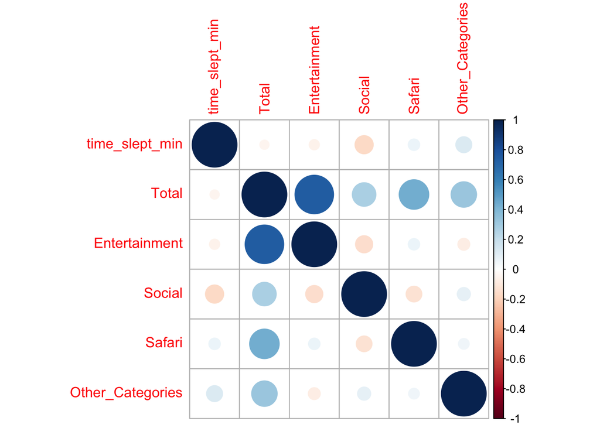

### Pairwised correlations between sleep time, total screen time, and Apps

```
##                time_slept_min Total Bilibili Safari WeChat Insta OtherApps
## time_slept_min           1.00 -0.04    -0.05   0.07  -0.13 -0.03      0.07
## Total                   -0.04  1.00     0.74   0.44   0.21  0.12      0.34
## Bilibili                -0.05  0.74     1.00   0.07  -0.15  0.05     -0.07
## Safari                   0.07  0.44     0.07   1.00  -0.17  0.01      0.07
## WeChat                  -0.13  0.21    -0.15  -0.17   1.00 -0.11      0.03
## Insta                   -0.03  0.12     0.05   0.01  -0.11  1.00     -0.08
## OtherApps                0.07  0.34    -0.07   0.07   0.03 -0.08      1.00
```

[figure not shown]

### Sleep time vs. Day Type on Weekdays and Weekends

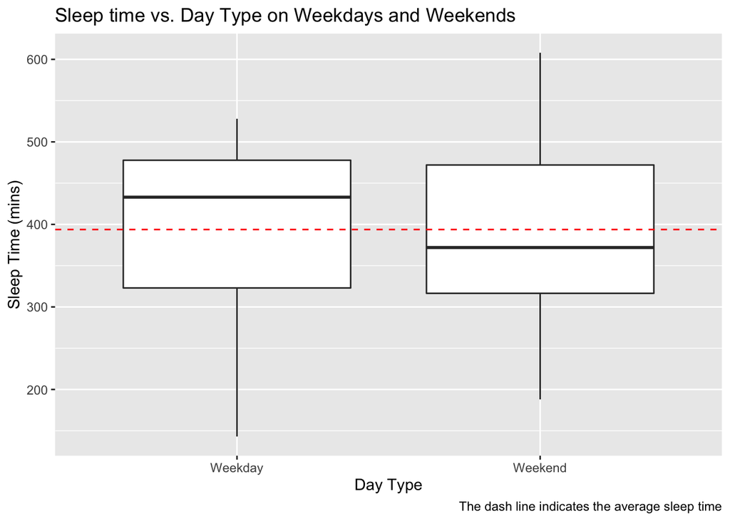

### The Screen Time vs Sleep Time by Day Type

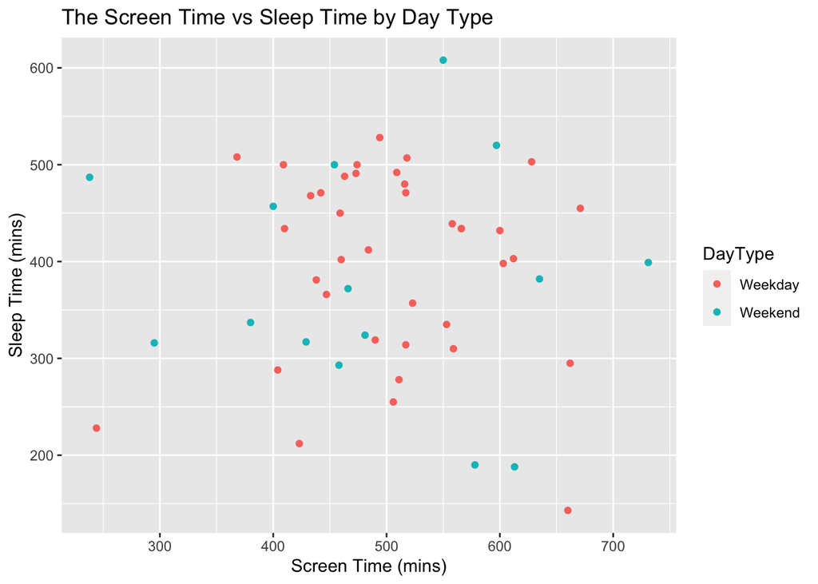

### Histogram of Sleep Time by Day Type

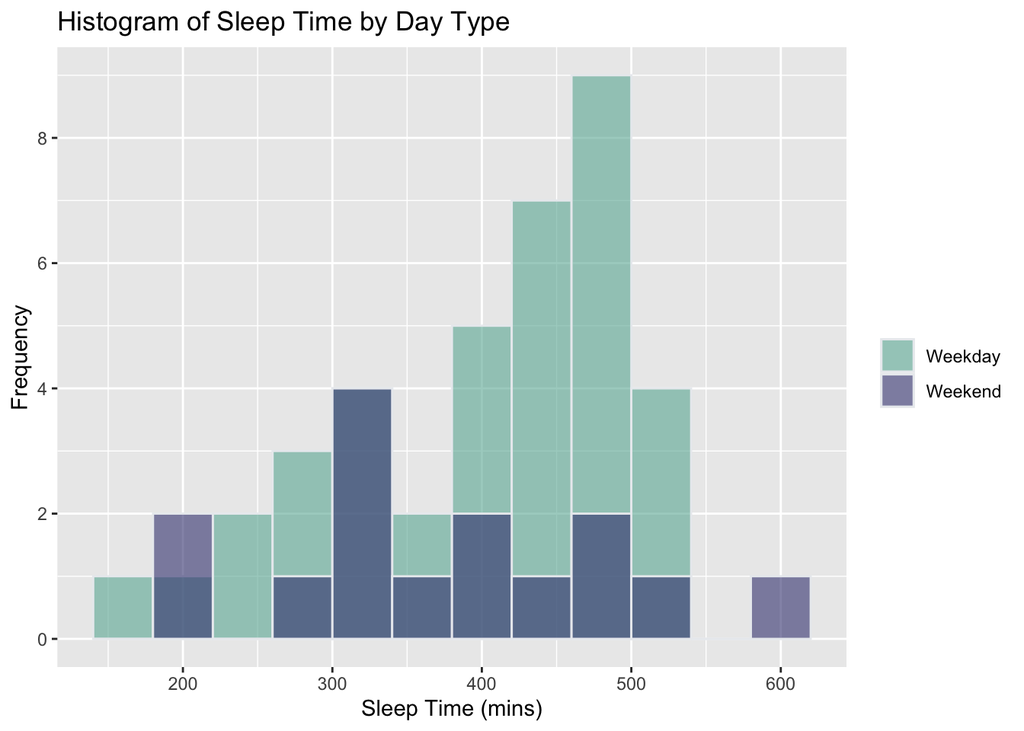

### Histogram of Screen Time by Day Type

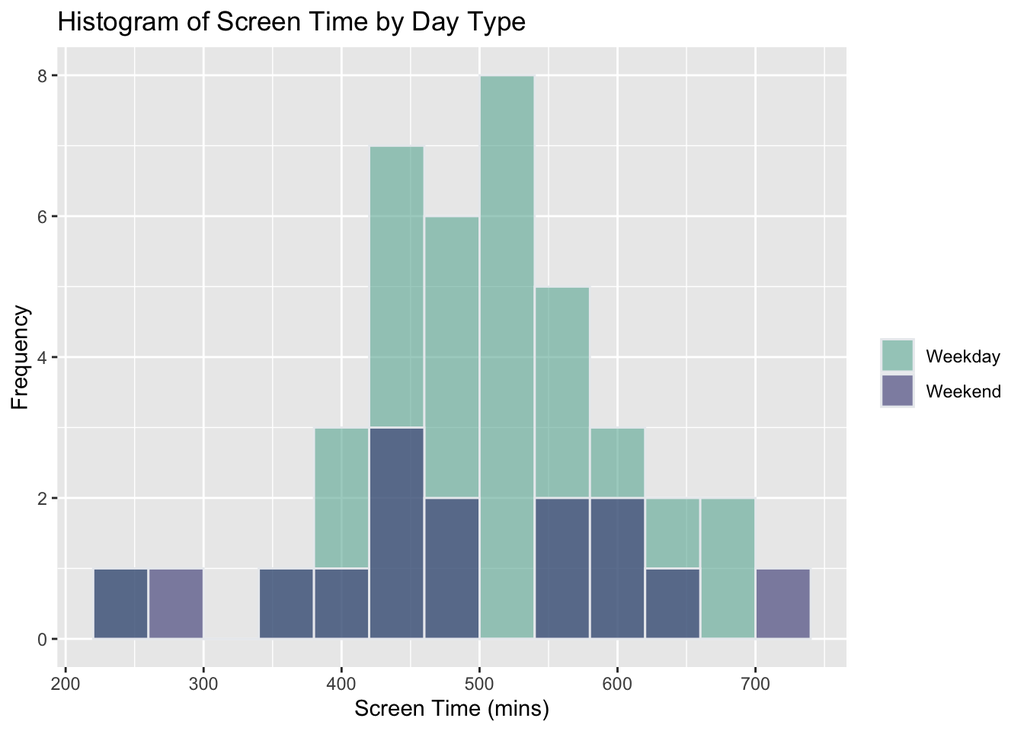

### Sleep Time vs. Screen Time Fitted with Linear Regression

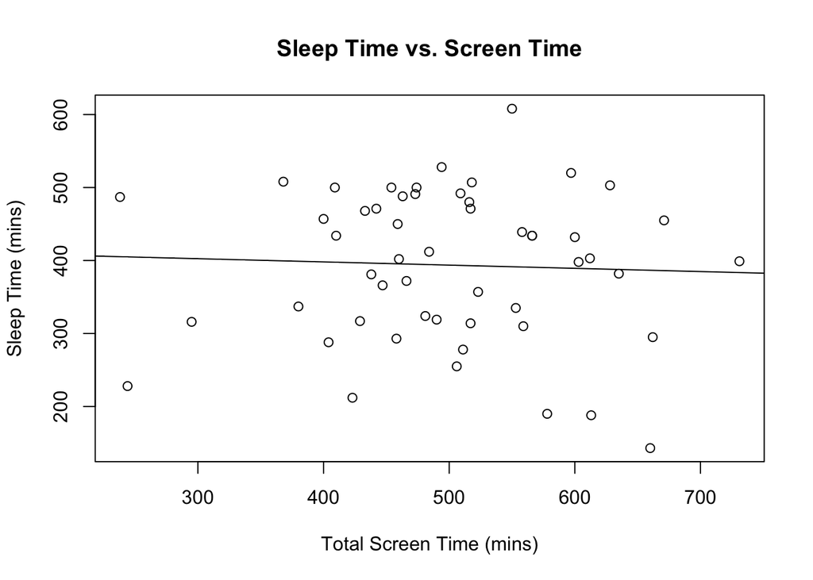

### Boxplot: Screen time vs. Day Type

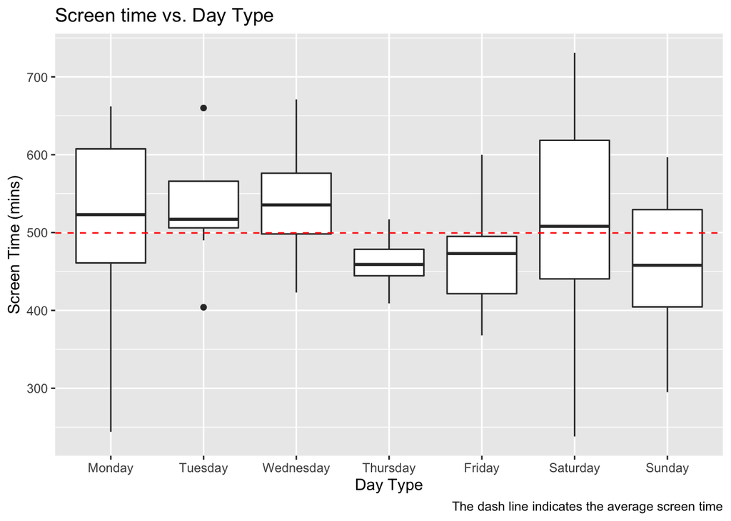

### Boxplot: Sleep time vs. Day Type

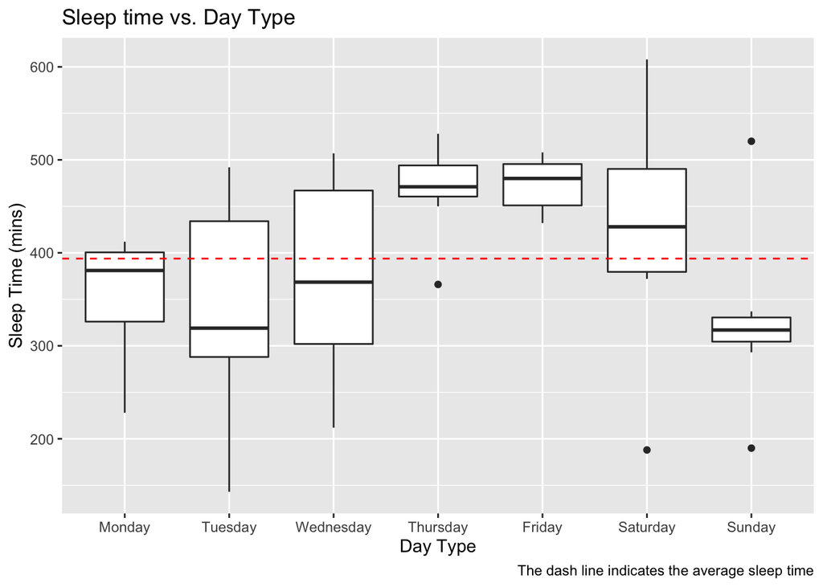